# Clustering

### Applications:

- Recommendor Systems
- Grouping similar people
- Data Compression

## K-Means:

K-means minimizes the distances within a cluster and maximizes the distance between clusters.

Random points are chosen and clusters of nearest points are made. A centriod is found from these clusters and this process is repeated until the clusters don't change.

A flaw in this method is the number of clusters must be predetermined.

```python
import matplotlib.pyplot as plt
from sklearn import datasets
import numpy as np
from sklearn.cluster import KMeans

# Importing a loading Iris dataset
X, y = datasets.load_iris(return_X_y = True)

# Three clusters are made for each flower category
model = KMeans(n_clusters=3)
model.fit(X)
y_labels = model.predict(X)
```

### Evaluating Clusters

Compare clustering to real flower label.

The graph below shows sepal length an actual flower categorization, along with how the KMeans model clustered the data.

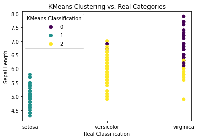

```python
x_labels = ['setosa','versicolor','virginica']
fig, ax = plt.subplots()
scatter = ax.scatter(x = y.astype(str), y = X[:,0], c = y_labels)
ax.set_ylabel('Sepal Length')
ax.set_xlabel('Real Classification')
ax.set_xticklabels(x_labels)
ax.set_title("KMeans Clustering vs. Real Categories")
ax.legend(*scatter.legend_elements(), title = "KMeans Classification")
fig.show()
```

### Evaluating a Cluster 2

For unlabeled data, look at how spread out the clusters are. Use the distance from each sample to centroid of its cluster. This is the inertia metric. Adding more clusters will lower the inertia, but you can have too many clusters. Choose a cluster number with high marginal change.

```
<function matplotlib.pyplot.show>
```

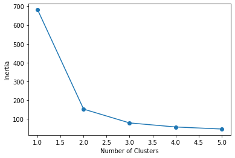

```python
ks = range(1,6)
inertias = []
for k in ks:
  model = KMeans(n_clusters= k)
  model.fit(X)
  inertias.append(model.inertia_)

plt.plot(ks, inertias, '-o')
plt.xlabel("Number of Clusters")
plt.ylabel("Inertia")
plt.show
```

### Transforming Data for Clusters

Clustering will be much more accurate and interpretable with scaled features. Use the StandardScaler to get equal variance.

```
<function matplotlib.pyplot.show>
```

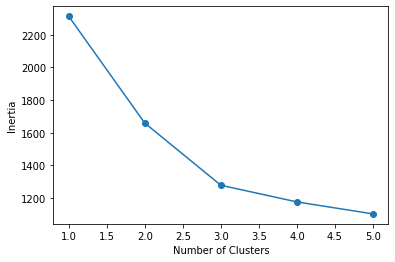

```python
from sklearn.preprocessing import StandardScaler
from sklearn.pipeline import make_pipeline

X_wine, target_wine = datasets.load_wine(return_X_y = True)

scale = StandardScaler()
newdata = scale.fit_transform(X_wine)

inertias = []
ks1 = range(1,6)

for k in ks1:
  model = KMeans(n_clusters= k)
  model.fit(newdata)
  inertias.append(model.inertia_)

plt.plot(ks, inertias, '-o')
plt.xlabel("Number of Clusters")
plt.ylabel("Inertia")
plt.show
```

### Visualizing Clusters

Agglomerative Hierarchy clustering: Every point has it's own cluster, at each step 2 closest clusters are merged. Visualize with dendogram tree.

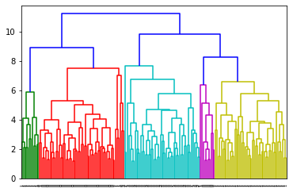

```python
from scipy.cluster.hierarchy import linkage, dendrogram
mergings = linkage(newdata, method = 'complete')
dendrogram(mergings, labels = target_wine)
plt.show()
```

## Hierarchical Clustering

Extract clusters from intermediate stage. Find intermediate clusters by defining a dendrogram height. This height is the max distance bewtween points. Distance is defined by linkage method ("complete").

## DBScan

Specify how close things have to be and minimum points in a cluster. Don't need to define the number of clusters

[output not shown]

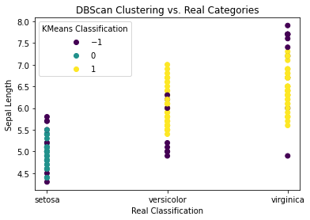

```python
from sklearn.cluster import DBSCAN
iris = datasets.load_iris()
X = iris.data[:, :2]
y = iris.target

db = DBSCAN(eps = 0.3, min_samples = 10)
db.fit(X)
labels = db.labels_

x_labels = ['setosa','versicolor','virginica']
fig, ax = plt.subplots()
scatter = ax.scatter(x = y.astype(str), y = X[:,0], c = labels)
ax.set_ylabel('Sepal Length')
ax.set_xlabel('Real Classification')
ax.set_xticklabels(x_labels)
ax.set_title("DBScan Clustering vs. Real Categories")
ax.legend(*scatter.legend_elements(), title = "KMeans Classification")
fig.show()
```